# Introduction

## What is Customer Relationship Management?

Customer relationship management (CRM) is a crucial component of a businesses success. CRM is software used by a company in an attempt to help them maintain solid relationships with their clients. It is critical for a company’s success specifically when a company is just getting started, specifically, a startup.

Within this project, we are acting as a travel startup with the hopes of building a platform to manage a small number of customers utilizing a basic data structure - a linked list.

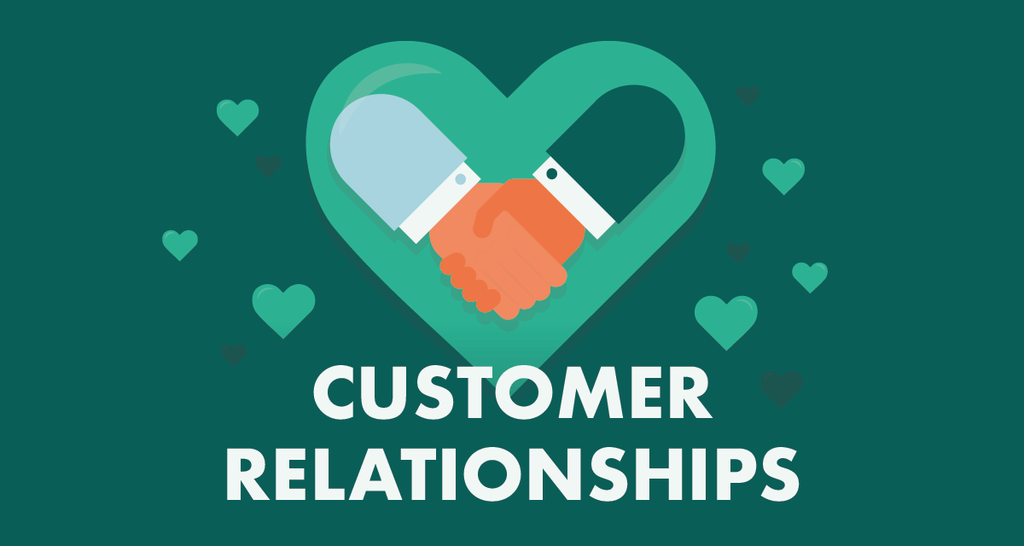

## What are Linked Lists?

Linked lists are the basis of many data structures. They are a fundamental concept in the world of computer science and they have the power to help construct a basic CRM system. A linked list consists of nodes where each node contains data and a reference link to the next node within a sequence. This structure allows for dynamic memory allocation and efficient insertion and deletion operations compared to arrays.(“Linked List Data Structure” n.d.)

Below is the basic structure of a linked list.

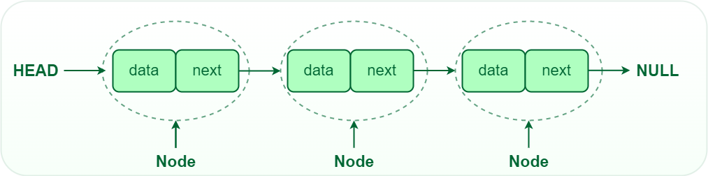

## CRM and Linked Lists

The linked list we have created will hold the power to update and edit customer information within the hypothetical CRM system that we are creating. Our CRM system includes client information including name, phone number, address, travel package bought, user ID, country and price. The linked list will allow the employees at the startup to easily access key information about their customers as well as display information to make reports.

The CRM system will have the ability to do things like adding customers, removing customers, updating information, and adding multiple packages.

## Our Startup

Our startup is a travel company that allows customers to purchase travel packages to countries all around the world. There are five different packages that the company currently offers:

1. Explorer’s Delight
2. Luxury Escapes
3. Budget Explore
4. Family Fun
5. Cultural Immersion

The customer has the option to choose one of these packages and the country they want to travel to, and our startup handles all the logistics.

To replicate real information being brought into the startup we have obtained data from the python library faker. You can learn more about Faker [here](https://faker.readthedocs.io/en/master/).

The faker data creates a customer and includes:

- Name
- Address
- Phone Number
- Country
- Plan
- Price

## Beyond Linked Lists

We recognize that as this hypothetical startup would grow, the linked list would start to face many technical issues such as scalability and security concerns.

Linked lists can face scalability challenges as the size of the customer database grows. Insertions and deletions in a linked list can be inefficient, especially if the list becomes large. As the CRM system accumulates more customer data and interactions, the performance of the linked list may be inadequate for our startups needs. The solution could be considering more scalable data structures like a hash table.

Furthermore, linked lists may pose security risks, especially if not implemented securely. In a linked list, nodes can be easily manipulated or accessed if proper access controls are not in place. This vulnerability can lead to data breaches and unauthorized access to sensitive customer information. The solution to this would be to implement robust security measures such as authentication protocols to protect customer data stored in the CRM system.

Within this project we will keep our focus on a reliable linked list fully aware of what challenges could arise in the future.

## Objectives

This project will walk through the power of a linked list and how crucial it is to computer scientists in truly understanding the fundamentals of data structures and how these structures are the underlying backbone of many software systems.

## References

“Linked List Data Structure.” n.d. *GeeksforGeeks*. Accessed April 29, 2024. https://www.geeksforgeeks.org/data-structures/linked-list/.